# Computing in the ’60s

~

2019-04-30

My dad was a mathematics teacher at Sartell High School and was also really into computing and programming. I remember learning BASIC with him on our Apple IIe and also programming our TI-99/4A. (To save a program on the TI, we had to hook up an external tape recorder and write to a cassette tape. Then to run the program, you played the tape!)

[figure not shown]

Old issues of *Byte*, *Compute*, *Family Computing* (check out the 1982 TV ad below), and other magazines and educational trades were stacked a mile-high in our living room; many providing the outlines of a program to create some graphical spectacle (e.g., a flashing Christmas tree or Jack-O-Lantern). Writing out the syntax to create these “masterpieces”, I began to learn how pixels on the computer screen could be manipulated to form images. I also experienced the anticipation of runnning the syntax only to have it fail because somewhere in the several 100 lines of code I just typed I missed a comma or semicolon, or mis-typed a digit…oh the drag of de-bugging.

[video not shown]

My dad and Dan Brockton (the Sartell librarian) were early advocates for teaching programming in the high school setting. They were also instrumental in bringing early computers into the school and getting students interested in using them. Below is an article that appeared in the high school paper about one of those computers, the [Programma 101](https://www.sacatech.com/blog-Programma-101-the-first-personal-computer.php).

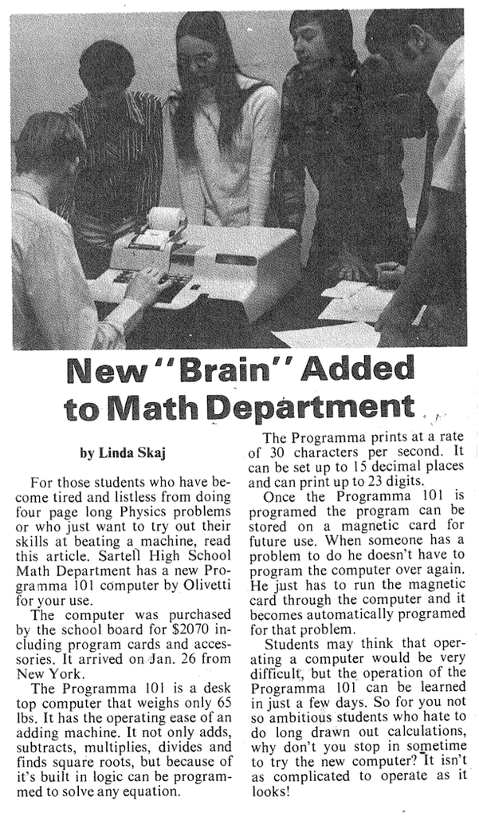

There are several things that stand out from this article (not the least is the gendered use of language, although it was great to see at least one female in the picture).

1. The cost of that thing was $2070.
2. It prints at a rate of 30 characters per second.
3. Data was stored on a magnetic card.
4. Apparently at that time, that machine looked complicated.